# Your menstrual cycle

# Example Feedback Report (a work in progress)

## Introduction

**Thank you for participating in The Daily Cycle Diary.** Your personal feedback has been compiled automatically for you on this web page. Above you can see the rough upper categories of the feedback. If you click on one, you get to more explanations and the graphics, as well as further explanations. All of the analyses and plots are based on the data you provided over the past month or so, and there are a few things you should note:

- Patterns seen here could be misleading. Remember that you are the expert for the interpretation of your data, not us.
- If a pattern makes no sense to you at all, it could be random error, our measures too brief, or the past month have simply been unusual.
- These data are not experimental, so we cannot say there is a cause-effect relationship. This is especially the case if you didn’t contribute data very regularly.
- This feedback is technically quite complex to create, and much of it was not designed by us but by our collaborator [Dr Ruben Arslan](https://rubenarslan.github.io/) who has much more experience in this area than we do. Any praise you have should largely be directed to him, and any problems you see were probably our fault. We're still developing these reports to make them the best that they can be. If you notice errors or ways to improve them, contact us via email.

In terms of interpreting the graphs, this information might help.

- Some women have shorter and longer cycles than others, and some women’s cycles are quite irregular. If your cycle length is significantly shorter or longer than that of other women (approximately 29 days on average), or your cycle is often irregular, then the fertile window (in blue) may not be positioned correctly.
- We count backwards the days from the beginning of the last menstruation. We do this because the last fortnight of the cycle (from ovulation to menstruation) is less variable than the first fortnight of the cycle. This means that data at the end of the diary can sometimes not be included (which is why we included a follow-up survey).
- In our research, we have so far found that hormonal contraceptive users do not demonstrate many behavioral changes across the menstrual cycle, compared to women who are not taking hormonal contraceptives.

## Your personality

### Big 5 personality

The Big Five or, more closely related, the five-factor model (FFM) is a model of personality psychology, which summarizes personality in five main dimensions: Neuroticism, extraversion, openness to experience, agreeableness and conscientiousness. Values on these dimensions serve as a simple summary of the ways in which people differ.

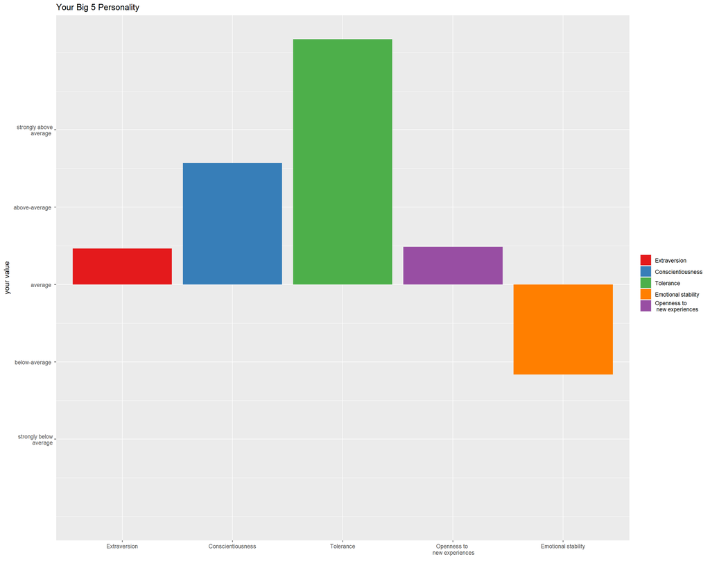

### Extraversion

The dimension extraversion describes activity and interpersonal behavior. It is also called enthusiasm and is contrasted with the introversion. People with high extraversion values are sociable, active, talkative, person-oriented, warm, optimistic and cheerful. They are also receptive to suggestions and excitement. Introverts are reluctant to socialize, like to be alone and independent. They can also be very active, but less so in company.

*We measured extraversion by asking how likely you were to describe yourself as dominant, assertive, unauthorative, or shy each day.*

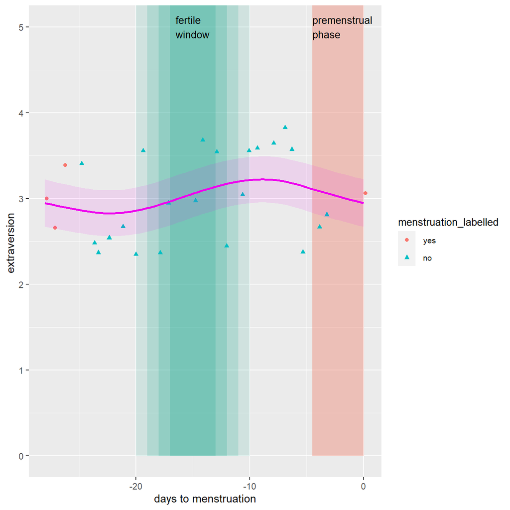

### Agreeableness

A key feature of people with agreeableness is their altruism. They treat others with understanding, benevolence and compassion, they try to help others, and they are convinced that they will behave just as helpful. They tend to trust each other, to cooperate and to be flexible. In contrast, people with low agreeableness levels describe themselves as antagonistic, self-centered and suspicious of other people’s intentions. They behave more competitively than cooperatively. So the positive side of the dimension seems to be clearly more socially desirable. However, it should not be forgotten that the ability to fight for one’s own interests is helpful in many situations. So agreeableness is not necessarily a virtue.

*We measured agreeableness by asking how likely you were to describe yourself as tender-hearted, gentle-hearted, cold-hearted, or unsympathetic each day.*

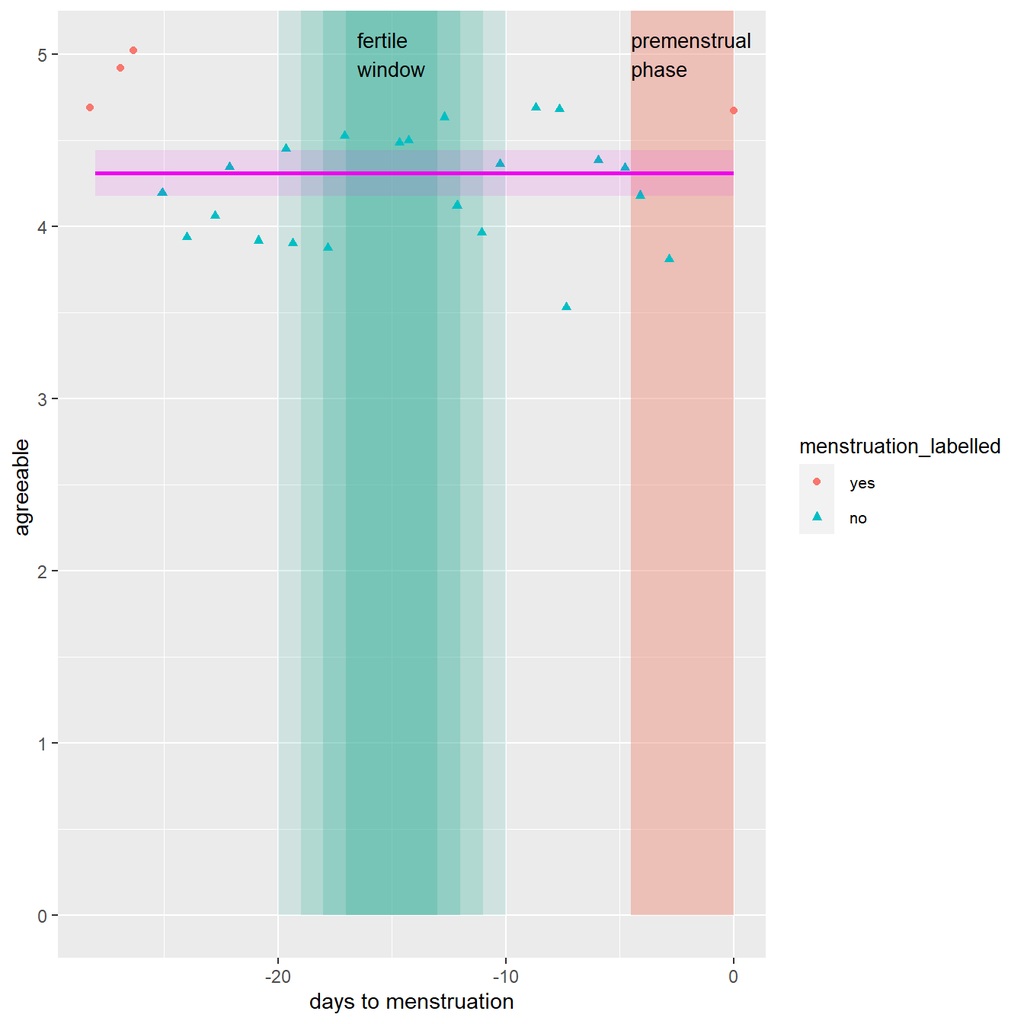

### Conscientiousness

People with high levels of conscientiousness act in an organized, careful, planning, effective, responsible, reliable and well-considered manner. Conscientious people are aware of the responsibility of their tasks and work purposefully and decisively towards their goals. People with low levels of conscientiousness act carelessly, spontaneously and inaccurately, but are also considered to be more relaxed and less motivated to perform. Low conscientiousness people are less at risk of perfectionism and compulsiveness. They talk more openly about sex, buckle up less often and take hitchhikers with them. They are also more prone to daydreaming and procrastination.

*We measured conscientiousness by asking how likely you were to describe yourself as organised, orderly, disorganised, or unorderly each day.*

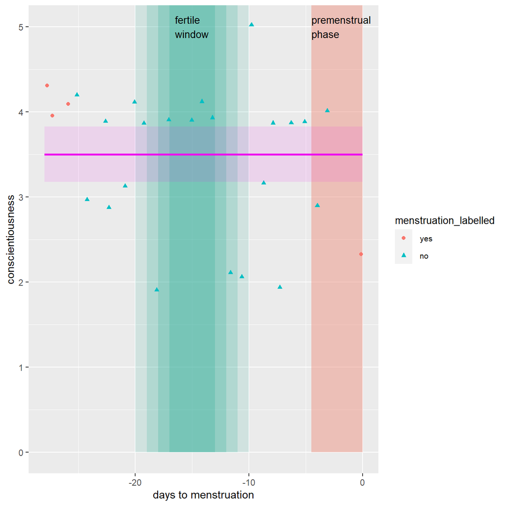

### Neuroticism

Neuroticism reflects individual differences in the experience of negative emotions and is also referred to by some people as emotional instability. Emotionally unstable people experience fear, nervousness, tension, grief, insecurity and embarrassment more often. In addition, these sensations persist longer and are more easily triggered. They tend to be more concerned about their health, to have unrealistic ideas, and have trouble being comfortable with stressful situations. Emotionally stable people tend to be calm, satisfied, stable, relaxed and safe. They experience negative feelings less often and positive feelings more often.

*We measured neuroticism by asking how likely you were to describe yourself as worrying, tense, relaxed, or at-ease each day.*

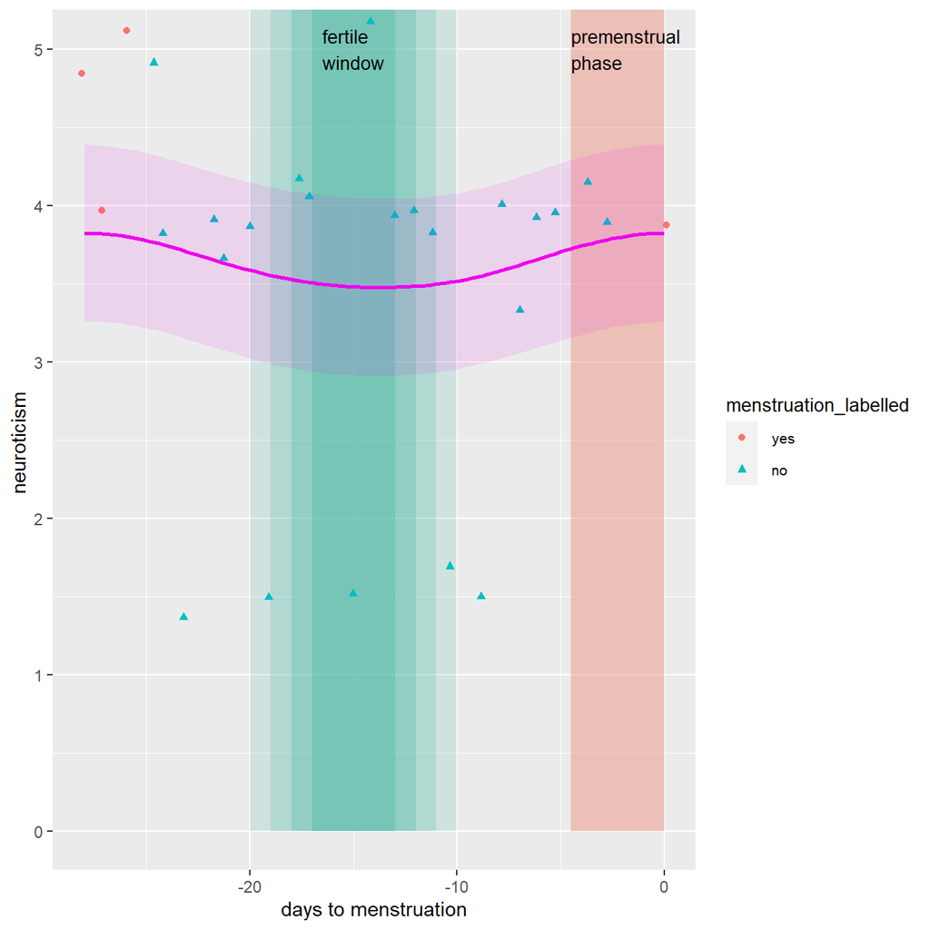

### Openness

This characteristic expresses the interest and the extent of preoccupation with new experiences, experiences and impressions. People with high openness often state that they have a lively fantasy life, clearly perceive their positive and negative feelings and are interested in many personal and public processes. They describe themselves as curious, intellectual, imaginative, keen to experiment and interested in art. They are more willing to critically question existing norms and to respond to new social, ethical and political values. They are independent in their judgment, often behave in an unconventional manner, try new ways of doing things and prefer variety. On the other hand, people with low openness tend to be more conventional and conservative. They prefer the familiar and the tried-and-tested to the new, and they perceive their emotional reactions rather subdued.

*We measured openness by asking how likely you were to describe yourself as philosophical, abstract-thinking, unphilosophical, or uninquisitive each day.*

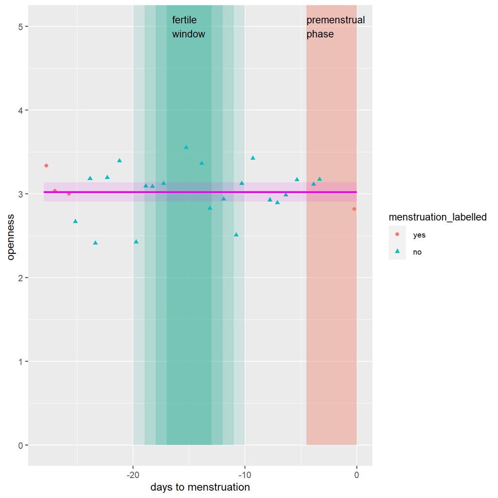

## Your emotions

### Positive affect

Positive affect refers to a set of emotions that reflect a pleasurable engagement with the environment. High levels of positive affect reflect enthusiasn, alertness, and active mood states. A lack of positive affect is often thought to reflect lethargy and sadness. Positive affect has also been considered as reflecting contentment, joy, and love.

*We measured positive affect by asking whether you felt cheerful, happy, excited, or relaxed each day.*

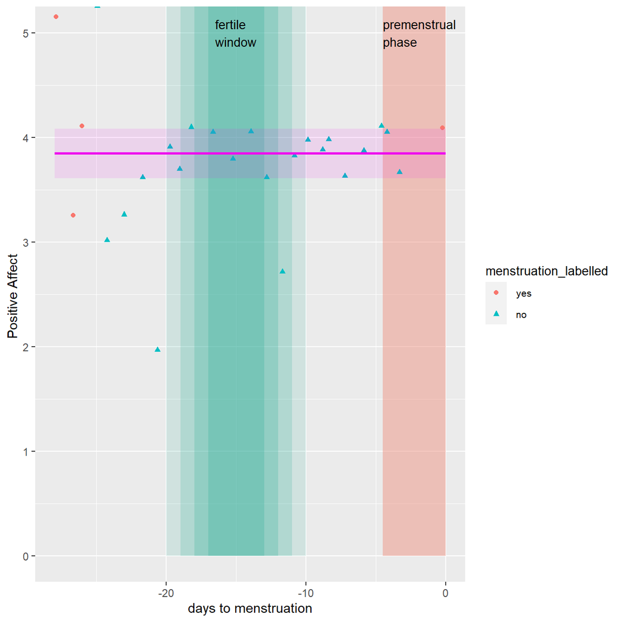

### Negative affect

Negative affect refers to a set of emotions that reflect a negative engagement with the environment. Negative affect is closely tied to neuroticism, and people who experience it a lot may take a gloomy view of things and tend toward worrying. Negative affect can be related to difficulties in coping with stress, and shows up in people who are sensitive to potentially threatening situations. A lack of negative affect can reflect calmness and serenity.

*We measured negative affect by asking whether you felt sad, guilty, angry, or nervous each day.*

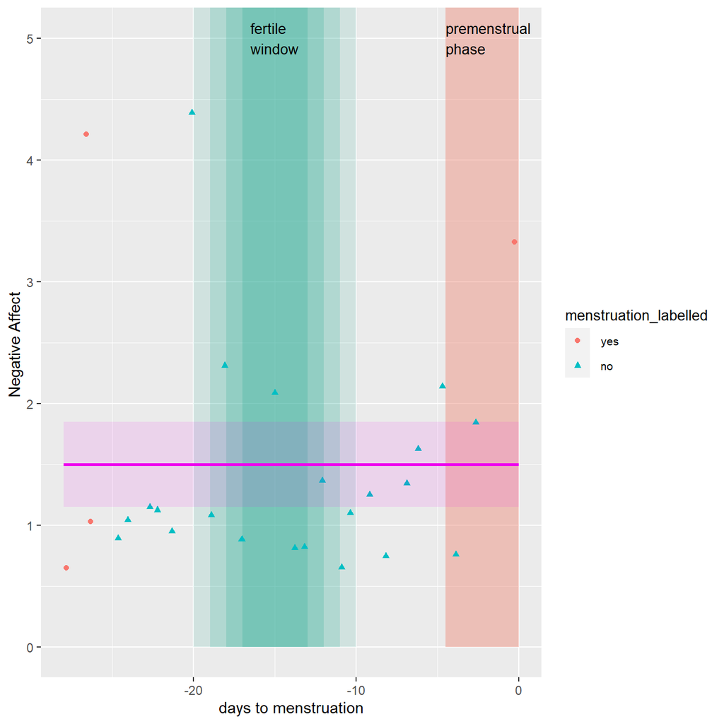

## Your action states

### Self-esteem

High self-esteem is defined as having a positive self-evaluation or self-concept. Self-esteem is important influencer of your actions and attitude. People who have high self-esteem are more likely to aggressively pursue their goals and viewed as more friendly and pleasant by others. Conversely, people with low self-esteem as less forthright in pursuing their goals and usually think worse of themselves.

*We measured self-esteem in three domains: your performance, your social esteem, and your appearance esteem. The specific items are listed below.*

1. I felt confident about my abilities.
2. I felt as smart as others.
3. I was worried about what other people thought of me.
4. I felt concerned about the impression I was making.
5. I felt satisfied with the way my body looked.
6. I was pleased with my appearance.

Below, we averaged results across all items to form an indicator of your global self-esteem across your menstrual cycle.

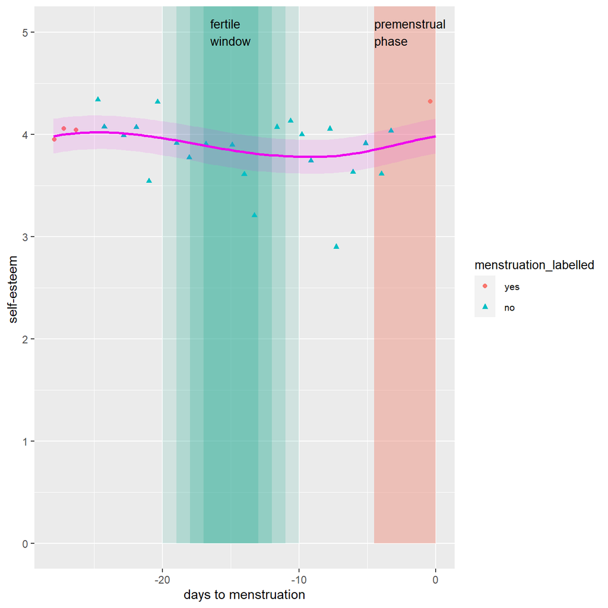

### Assertiveness

Assertiveness refers to the ability to express yourself in social contexts, despite there being barriers. Assertiveness is a skill that allows you to stand up for yourself or others’ rights in a calm and positive way. Assertive people get their point across without becoming upset or upsetting others. People who are not assertive find this very difficult, and have trouble communicating themselves effectively.

*We measured assertiveness by asking the extent to which you affected your environment, efficiently achieved your goals, tried to assert and expand yourself, or preferred to go with the flow each day.*

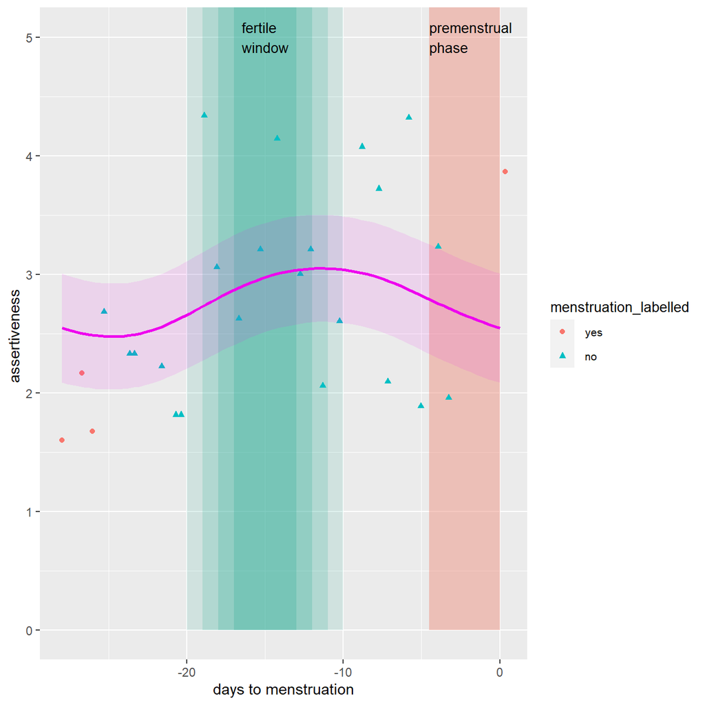

### Impulsiveness

Impulsivity is a complex contruct with many components. It generally refers to the ability to react quickly without forethought or self-control, and failing to pay attention is associated with high impulsivity. However, impulsivity is not always a bad thing. A race-car driver, for example, needs to be able to think quickly without second-guessing themselves, which is an example of an impulsive trait. Impulsivity is an important feature in risky behaviour more generally, including risky sexual behaviour and alcohol and drug use. Sometimes impulsivity is a totally normal response, but other times it can be problematic (depending on your goals).

*We measured impulsivity using the Short UPPS Impulsive Behaviour Scale (SUPPS-P). The SUPPS-P measures five distinct facets of impulsivity, which are negative urgency (a strong urge to act when feeling bad), lack of perseverance, a lack of premeditation, sensation-seeking, and positive urgency (a strong urge to act when feeling good). We averaged your responses to each of these facets each day, to provide an indicator of your impulsiveness across your menstrual cycle.*

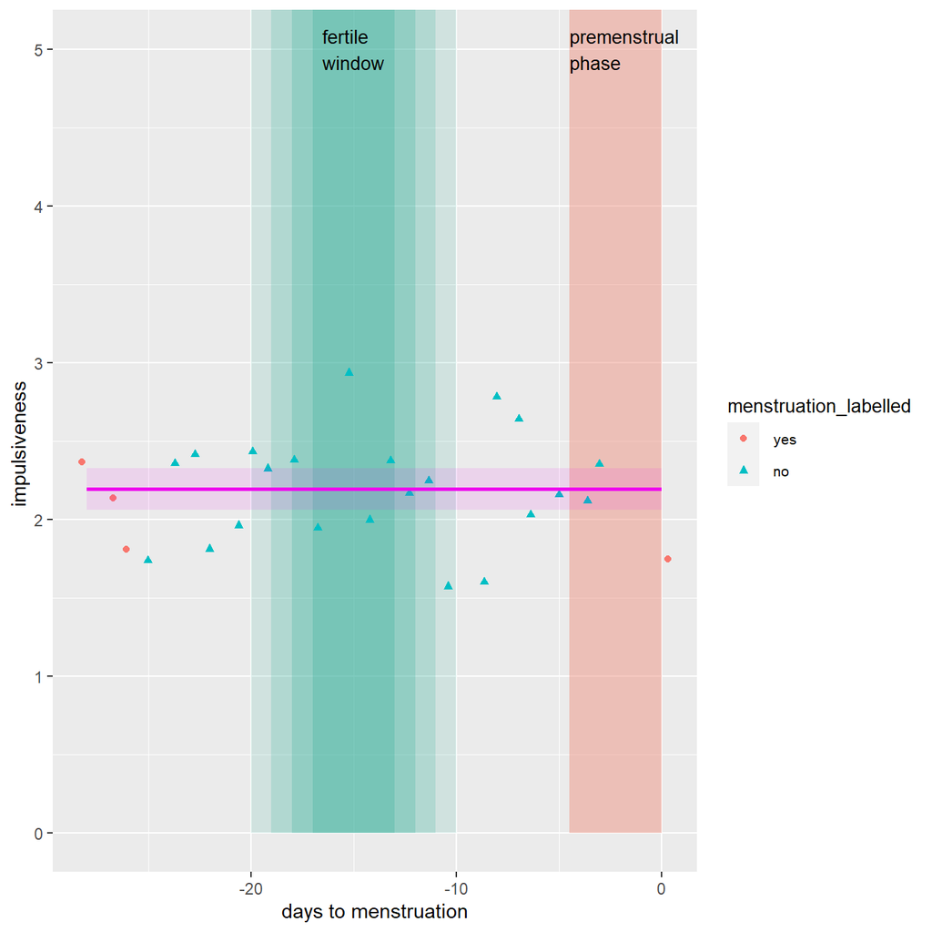

## Your health

### Dieting behaviour

One of the things we looked at in the Daily Cycle Diary was your dieting behaviour over the menstrual cycle. We derived these items based on the Eating Attitudes Test (EAT-26) and its shortened version (EAT-8). Specifically, we asked the extent to which you engaged in binge eating or dieting behaviour, felt guilty about what you ate, or worried about your weight on each day of your menstrual cycle.

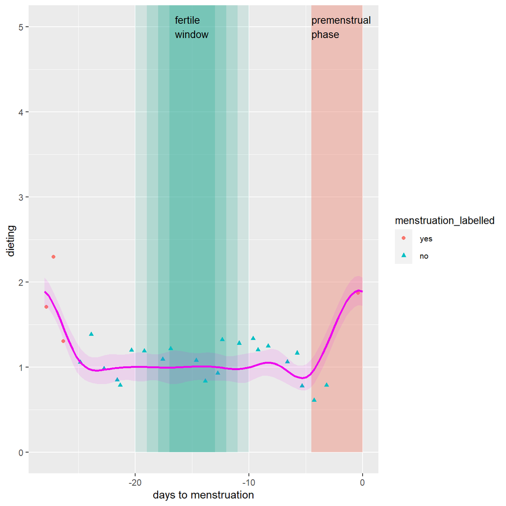

### Sleep

We also looked at the quality of your sleep across your menstrual cycle. Getting a good night’s sleep is linked to many positive outcomes, and refers to sleeping more often, falling asleep easily, and waking up irregularly throughout the night.

*We measured your sleep quality compared to usual by asking whether you slept better or worse than usual on each day of your cycle.*

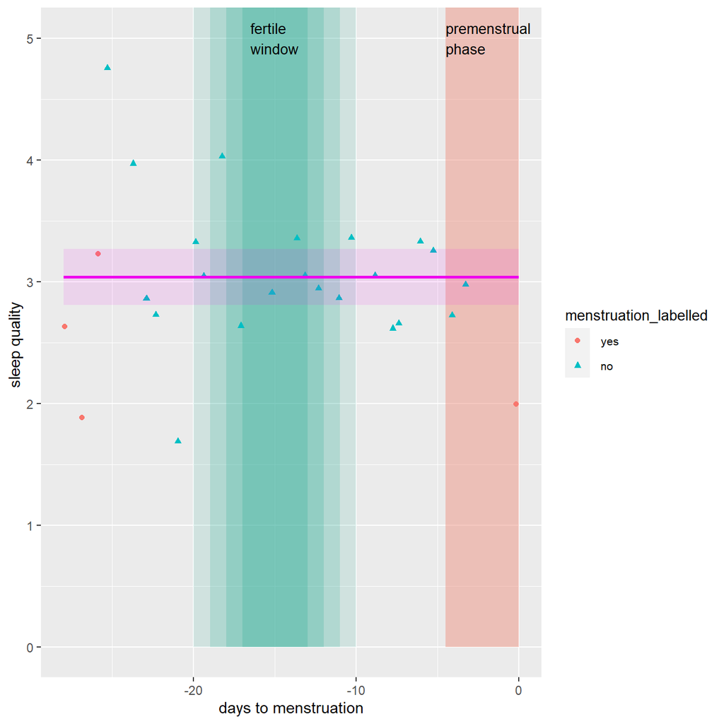

### Health

Your ratings of your own health is another thing we measured in the Daily Cycle Diary.

*We measured your perceived health by asking whether your health was better or worse than usual on each day of your cycle.*

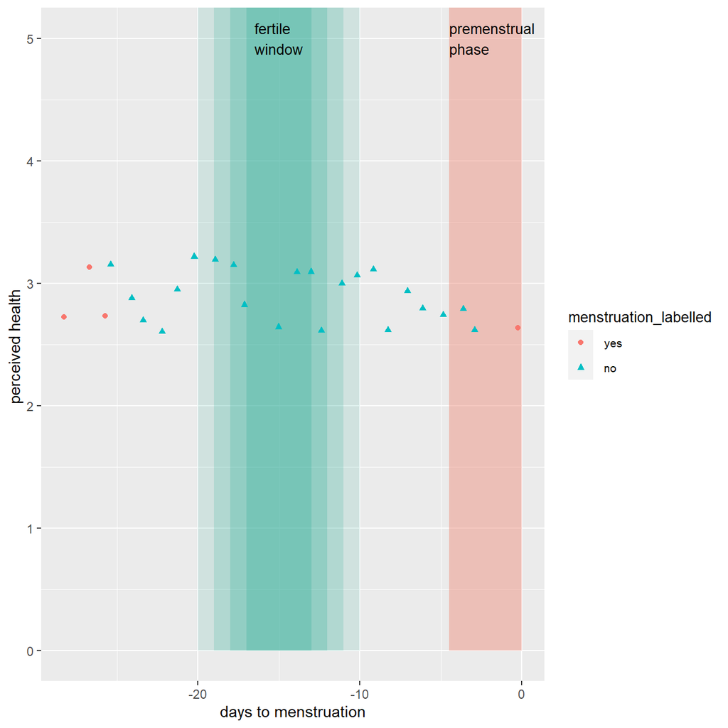

## Your intimacy

### Relationship intimacy

Intimacy refers to a feeling of close familiarity within a personal relationship. Intimacy builds as you connect with someone and get to know them, and is often characterized by loving trust and support. We were interested in whether you felt more or less intimacy with your romantic partner (if you had one) on different days of your menstrual cycle.

*We measured intimacy by asking, if you had a romantic partner, whether you cuddled them or were affectionate with them each day.*

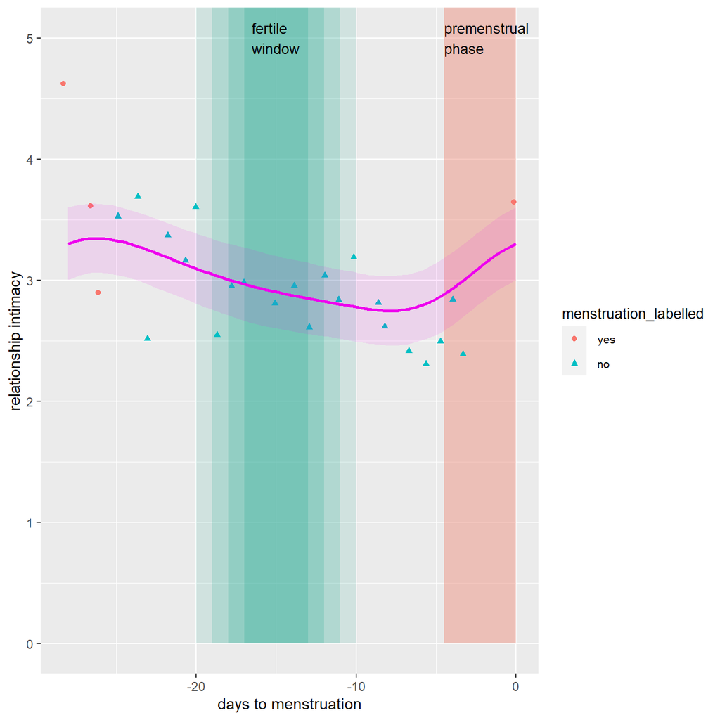

### Sexual desire

Sexual desire is a motivational state that encourages an interest in sexual activities or objects. When you experience high sexual desire, you are more likely to engage in sexual activities. When people talk about sexual desire, they also talk about lust, libido, and sexual attraction.

*We measured your sexual desire compared to usual by asking whether you experienced more or less sexual desire compared to usual each day.*

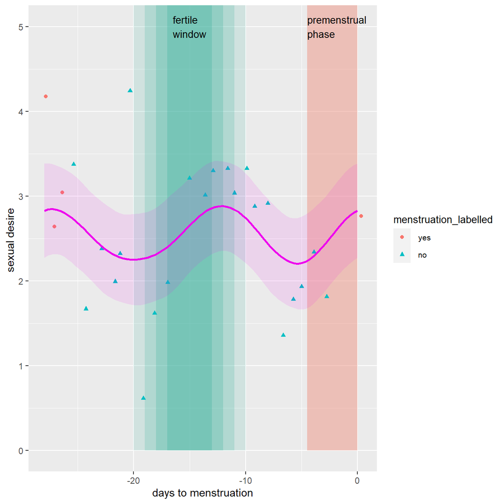